# Rasch_Model

Felix Eßer

8/9/2020

# 1 The Rasch Model

The Rasch model is a one-dimensional measurement model (latent-trait model) for dichotomous items

This document serves the purpose to illustrate the analysis of a Rasch model with marginal respect to the mathematical foundations. The focus will be on the implementation in R.

Within the Rasch model, two model assumptions are made:

1. Rasch homogeneity:
   - All $p$ items measure the same latent variable.
   - $$P(Y_i = 1|\eta) = \frac{e^{\eta - \alpha_i}}{1 + e^{\eta - \alpha_i}}$$
2. Local independence of items
   - The latent variable $\eta$ explains all correlations between the items.

Model assessment

1. Equality of item parameters in sub-populations 1.1 Andersen test (Conditional likelihood-quotient-test) 1.2 Graphical model test 1.3 Wald-test 1.4 Rasch-mixture-analysis
2. Global model validitiy 2.1 Probability distribution of response patterns 2.2 Likelihood-quotient-test
3. Equality of person scores in reduced Rasch models

# 2 Packages to analyse Rasch Models

Of course there are different `R` packages available to analyse a Rasch model:

- `eRm` - extended Rasch model
- `ltm` - latent trait model and
- `TAM` - Test Analysis Modules

There are different advantages of these packages - different analyses can be performed to assess the model validity.

```r
# Packages to perform Rasch models
library(eRm)
library(ltm)
library(TAM)

# Additional packages
library(psychomix) # to fit finite mixtures of Rasch models
library(psych) # to calculate Yules' Q
library(tidyverse) # data transformation, plotting, etc.
```

```r
data(raschdat1) # load data from eRm package
raschdat1 %>%
  summarise_all(list(Mean = mean, Variance = var)) %>%
  pivot_longer(cols = everything(),
               names_to = c("Item", "Statistic"),
               names_pattern = "(I\\d+)_(.+)",
               values_to = "Value") %>%
  pivot_wider(id_cols = Item,
              names_from = Statistic,
              values_from = Value)
```

```
## # A tibble: 30 x 3
##    Item   Mean Variance
##    <chr> <dbl>    <dbl>
##  1 I1    0.76     0.184
##  2 I2    0.47     0.252
##  3 I3    0.62     0.238
##  4 I4    0.33     0.223
##  5 I5    0.22     0.173
##  6 I6    0.48     0.252
##  7 I7    0.6      0.242
##  8 I8    0.61     0.240
##  9 I9    0.570    0.248
## 10 I10   0.25     0.189
## # … with 20 more rows
```

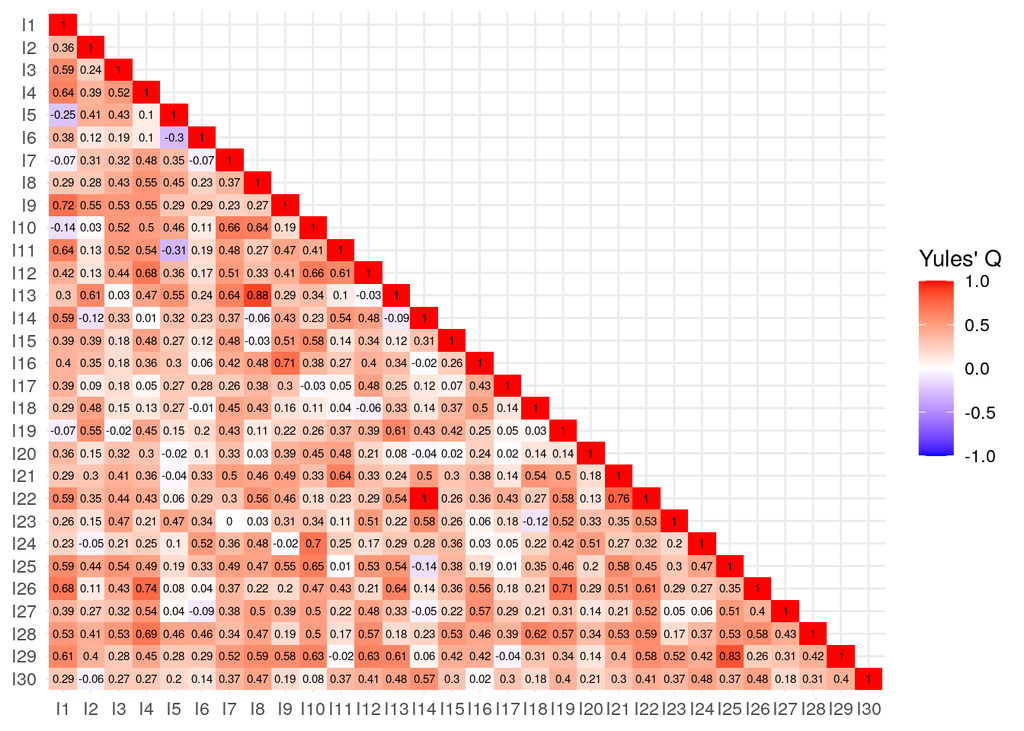

```r
yules_mat <- matrix(nrow = ncol(raschdat1), ncol = ncol(raschdat1),
                    dimnames = list(colnames(raschdat1), colnames(raschdat1)))

for (i in 1:nrow(yules_mat)) {
  for (j in 1:ncol(yules_mat)) {
    yules_mat[i,j] <- Yule(table(raschdat1[,i], raschdat1[,j]))
  }
}

yules_mat %>%
  # convert to tibble
  as_tibble() %>%
  # add variable names as column
  mutate(variable_1 = colnames(.)) %>%
  # transform in wide format
  pivot_longer(cols = -variable_1,
               names_to = "variable_2",
               values_to = "Yules_Q") %>%
  # drop upper triangle of correlation matrix
  filter(as.integer(str_extract(variable_1, "\\d+")) <=
           as.integer(str_extract(variable_2, "\\d+"))) %>%
  # transform variables to factors
  mutate(variable_1 = factor(variable_1,
                             levels = str_c("I", 1:length(unique(variable_1)))),
         variable_2 = factor(variable_2,
                             levels = rev(levels(variable_1)))) %>%
  # create plot
  ggplot(aes(x = variable_1, y = variable_2, fill = Yules_Q)) +
  geom_tile() +
  geom_text(aes(label = round(Yules_Q, 2)), size = 2) +
  scale_fill_gradient2(low = "blue", high = "red", mid = "white",
                       midpoint = 0, limit = c(-1, 1),
                       name = "Yules' Q") +
  theme_minimal() +
  theme(axis.title = element_blank())
```

# 3 Rasch Model with the `eRm` package

```r
# Fit of Rasch Model with conditional maximum likelihood
rasch_model <- RM(raschdat1,
                  sum0 = TRUE) # sum0 = Normed to sum = 0; default

summary(rasch_model)
```

```
##
## Results of RM estimation:
##
## Call:  RM(X = raschdat1, sum0 = TRUE)
##
## Conditional log-likelihood: -1434.482
## Number of iterations: 28
## Number of parameters: 29
##
## Item (Category) Difficulty Parameters (eta): with 0.95 CI:
##     Estimate Std. Error lower CI upper CI
## I2    -0.051      0.216   -0.475    0.373
## I3    -0.782      0.222   -1.217   -0.347
## I4     0.650      0.228    0.204    1.096
## I5     1.301      0.254    0.802    1.799
## I6    -0.099      0.216   -0.523    0.324
## I7    -0.682      0.220   -1.113   -0.250
## I8    -0.732      0.221   -1.165   -0.299
## I9    -0.534      0.218   -0.961   -0.106
## I10    1.108      0.245    0.628    1.587
## I11    0.650      0.228    0.204    1.096
## I12   -0.388      0.217   -0.813    0.037
## I13    1.511      0.267    0.988    2.034
## I14    2.116      0.316    1.497    2.735
## I15   -0.340      0.216   -0.764    0.085
## I16    0.597      0.226    0.154    1.041
## I17   -0.340      0.216   -0.764    0.085
## I18    0.094      0.217   -0.332    0.520
## I19    0.759      0.231    0.306    1.211
## I20   -0.682      0.220   -1.113   -0.250
## I21   -0.937      0.226   -1.379   -0.495
## I22   -0.989      0.227   -1.434   -0.544
## I23   -0.682      0.220   -1.113   -0.250
## I24   -0.003      0.217   -0.427    0.422
## I25    0.814      0.233    0.358    1.271
## I26   -1.207      0.234   -1.665   -0.749
## I27    0.094      0.217   -0.332    0.520
## I28    0.290      0.220   -0.140    0.721
## I29    0.759      0.231    0.306    1.211
## I30   -0.732      0.221   -1.165   -0.299
```

[output cut: 18 more lines]

```
## beta I16   -0.597      0.226   -1.041   -0.154
## beta I17    0.340      0.216   -0.085    0.764
## beta I18   -0.094      0.217   -0.520    0.332
## beta I19   -0.759      0.231   -1.211   -0.306
## beta I20    0.682      0.220    0.250    1.113
## beta I21    0.937      0.226    0.495    1.379
## beta I22    0.989      0.227    0.544    1.434
## beta I23    0.682      0.220    0.250    1.113
## beta I24    0.003      0.217   -0.422    0.427
## beta I25   -0.814      0.233   -1.271   -0.358
## beta I26    1.207      0.234    0.749    1.665
## beta I27   -0.094      0.217   -0.520    0.332
## beta I28   -0.290      0.220   -0.721    0.140
## beta I29   -0.759      0.231   -1.211   -0.306
## beta I30    0.732      0.221    0.299    1.165
```

## 3.1 Itemcharactersic function

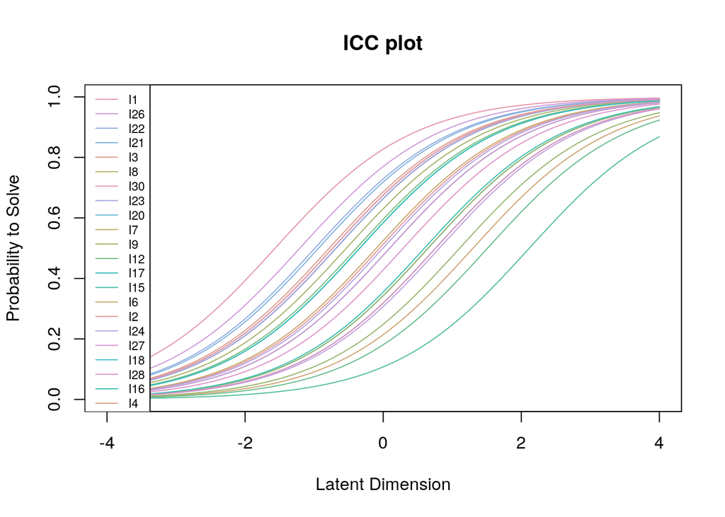

```r
plotjointICC(rasch_model)
```

```r
#plotICC(rasch_model, ask = FALSE) # get ICC for every item
```

```r
person_rasch <- person.parameter(rasch_model)
print(person_rasch) # max number of correct answers was 26; nobody solved no item
```

```
##
## Person Parameters:
##
##  Raw Score    Estimate Std.Error
##          1 -3.66742609 1.0263431
##          2 -2.92018929 0.7447193
##          3 -2.45940428 0.6239500
##          4 -2.11498445 0.5545223
##          5 -1.83351152 0.5090790
##          6 -1.59110856 0.4771411
##          7 -1.37496291 0.4537329
##          8 -1.17730648 0.4361574
##          9 -0.99308018 0.4228273
##         10 -0.81875439 0.4127478
##         11 -0.65161963 0.4052604
##         12 -0.48961902 0.3999339
##         13 -0.33116831 0.3964819
##         14 -0.17480565 0.3947168
##         15 -0.01916876 0.3945336
##         16  0.13692217 0.3958981
##         17  0.29469628 0.3988374
##         18  0.45551900 0.4034497
##         19  0.62079886 0.4099127
##         20  0.79218593 0.4185046
##         21  0.97181979 0.4296525
##         22  1.16239972 0.4439974
##         23  1.36749854 0.4625197
##         24  1.59228399 0.4867828
##         25  1.84461465 0.5194398
##         26  2.13743169 0.5653932
```

```r
summary(person_rasch)
```

```
##
## Estimation of Ability Parameters
##
## Collapsed log-likelihood: -380.2469
## Number of iterations: 13
## Number of parameters: 26
##
## ML estimated ability parameters (without spline interpolated values):
##               Estimate Std. Err.      2.5 %       97.5 %
## theta P1   -3.66742609 1.0263431 -5.6790216 -1.655830578
## theta P2   -2.92018929 0.7447193 -4.3798124 -1.460566210
## theta P3   -2.45940428 0.6239500 -3.6823238 -1.236484762
## theta P4   -2.11498445 0.5545223 -3.2018281 -1.028140766
## theta P5   -2.11498445 0.5545223 -3.2018281 -1.028140766
## theta P6   -2.11498445 0.5545223 -3.2018281 -1.028140766
## theta P7   -1.83351152 0.5090790 -2.8312879 -0.835735091
## theta P8   -1.59110856 0.4771411 -2.5262880 -0.655929118
## theta P9   -1.59110856 0.4771411 -2.5262880 -0.655929118
## theta P10  -1.59110856 0.4771411 -2.5262880 -0.655929118
## theta P11  -1.59110856 0.4771411 -2.5262880 -0.655929118
## theta P12  -1.59110856 0.4771411 -2.5262880 -0.655929118
## theta P13  -1.37496291 0.4537329 -2.2642631 -0.485662685
## theta P14  -1.37496291 0.4537329 -2.2642631 -0.485662685
## theta P15  -1.37496291 0.4537329 -2.2642631 -0.485662685
## theta P16  -1.37496291 0.4537329 -2.2642631 -0.485662685
## theta P17  -1.37496291 0.4537329 -2.2642631 -0.485662685
## theta P18  -1.17730648 0.4361574 -2.0321593 -0.322453632
## theta P19  -1.17730648 0.4361574 -2.0321593 -0.322453632
## theta P20  -1.17730648 0.4361574 -2.0321593 -0.322453632
## theta P21  -0.99308018 0.4228273 -1.8218065 -0.164353904
## theta P22  -0.99308018 0.4228273 -1.8218065 -0.164353904
## theta P23  -0.99308018 0.4228273 -1.8218065 -0.164353904
## theta P24  -0.99308018 0.4228273 -1.8218065 -0.164353904
## theta P25  -0.99308018 0.4228273 -1.8218065 -0.164353904
## theta P26  -0.81875439 0.4127478 -1.6277253 -0.009783507
## theta P27  -0.81875439 0.4127478 -1.6277253 -0.009783507
## theta P28  -0.81875439 0.4127478 -1.6277253 -0.009783507
## theta P29  -0.81875439 0.4127478 -1.6277253 -0.009783507
## theta P30  -0.81875439 0.4127478 -1.6277253 -0.009783507
## theta P31  -0.81875439 0.4127478 -1.6277253 -0.009783507
```

[output cut: 54 more lines]

```
## theta P86   0.97181979 0.4296525  0.1297164  1.813923187
## theta P87   0.97181979 0.4296525  0.1297164  1.813923187
## theta P88   0.97181979 0.4296525  0.1297164  1.813923187
## theta P89   0.97181979 0.4296525  0.1297164  1.813923187
## theta P90   1.16239972 0.4439974  0.2921807  2.032618707
## theta P91   1.16239972 0.4439974  0.2921807  2.032618707
## theta P92   1.16239972 0.4439974  0.2921807  2.032618707
## theta P93   1.16239972 0.4439974  0.2921807  2.032618707
## theta P94   1.36749854 0.4625197  0.4609766  2.274020439
## theta P95   1.59228399 0.4867828  0.6382073  2.546360706
## theta P96   1.84461465 0.5194398  0.8265313  2.862698024
## theta P97   2.13743169 0.5653932  1.0292813  3.245582047
## theta P98   2.13743169 0.5653932  1.0292813  3.245582047
## theta P99   2.13743169 0.5653932  1.0292813  3.245582047
## theta P100  2.13743169 0.5653932  1.0292813  3.245582047
```

Person-Item-Map

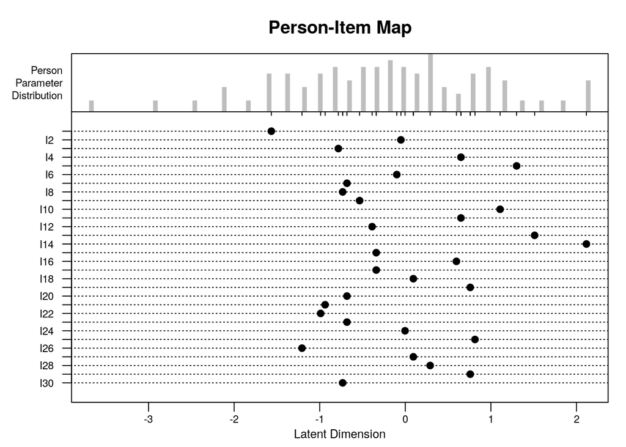

```r
plotPImap(rasch_model)
```

# 4 Model assessment

Test model validity

## 4.1 Equality of item parameters in sub-populations

### 4.1.1 Andersen Test

```r
lr_test <- LRtest(rasch_model, splitcr = "median" ) # split criterion median is the default
summary(lr_test)
```

```
##
## Andersen LR-test:
## LR-value: 32.542
## Chi-square df: 29
## p-value:  0.297
##
##
## Subject Subgroup: Raw Scores <= Median:
## Log-likelihood:  -748.7115
##
## Beta Parameters:
##           beta I1   beta I2   beta I3    beta I4    beta I5   beta I6   beta I7
## Estimate 1.536423 0.4061060 0.8885769 -1.1852731 -0.8503083 0.4061060 0.5701508
## Std.Err. 0.290337 0.2860538 0.2789390  0.4257245  0.3786451 0.2860537 0.2820759
##            beta I8   beta I9   beta I10   beta I11  beta I12  beta I13
## Estimate 0.5701508 0.5701508 -1.3902739 -0.7080244 0.3219844 -1.945273
## Std.Err. 0.2820759 0.2820759  0.4602704  0.3618716 0.2887422  0.579125
##            beta I14  beta I15   beta I16  beta I17  beta I18   beta I19
## Estimate -1.6358757 0.1479294 -0.7080244 0.6506106 0.2360489 -0.7080244
## Std.Err.  0.5080154 0.2957498  0.3618719 0.2807208 0.2919549  0.3618720
##           beta I20  beta I21  beta I22  beta I23   beta I24   beta I25
## Estimate 0.9675005 0.8095995 0.9675005 1.0465837 -0.1341910 -1.1852731
## Std.Err. 0.2790677 0.2791667 0.2790675 0.2795502  0.3114583  0.4257247
##           beta I26    beta I27   beta I28   beta I29  beta I30
## Estimate 1.0465837 -0.03665048 -0.4566168 -1.0077963 0.8095995
## Std.Err. 0.2795502  0.30539764  0.3365361  0.3994033 0.2791664
##
##
## Subject Subgroup: Raw Scores > Median:
## Log-likelihood:  -669.4995
##
## Beta Parameters:
##            beta I1    beta I2   beta I3    beta I4    beta I5    beta I6
## Estimate 1.7027031 -0.3365899 0.6200585 -0.3365899 -1.5741240 -0.2425755
## Std.Err. 0.5113294  0.3021572 0.3546427  0.3021573  0.3250141  0.3043952
##            beta I7   beta I8   beta I9   beta I10   beta I11  beta I12
## Estimate 0.9018107 1.0634043 0.4941077 -0.9794852 -0.6125924 0.4941077
## Std.Err. 0.3841033 0.4043206 0.3437077  0.3020922  0.2989299 0.3437079
##           beta I13   beta I14  beta I15   beta I16    beta I17   beta I18
## Estimate -1.365451 -2.3393394 0.6200585 -0.5212322 -0.04907755 -0.4293493
## Std.Err.  0.314425  0.3900885 0.3546431  0.2994549  0.31089221  0.3005225
##            beta I19  beta I20  beta I21 beta I22  beta I23  beta I24   beta I25
## Estimate -0.7950874 0.2628841 1.2449163 1.063404 0.1551400 0.1551400 -0.6125924
## Std.Err.  0.2994562 0.3269900 0.4301373 0.404321 0.3206186 0.3206184  0.2989296
##           beta I26   beta I27   beta I28   beta I29  beta I30
## Estimate 1.7026693 -0.1468922 -0.1468922 -0.6125924 0.6200585
## Std.Err. 0.5113797  0.3072850  0.3072851  0.2989296 0.3546429
```

The Andersen test yielded in a non-signifikant result, $\chi^2(29) = 32.54, p = .30$. Therefore, the null-hypotheses that the itemparameters are the same can be maintained.

## 4.2 Graphical model test

By means of the function `plotGOF` from the `eRm` package, it is possible to obtain a plot in which the itemparameters of the andersen test are shown in respect to the split criterion.

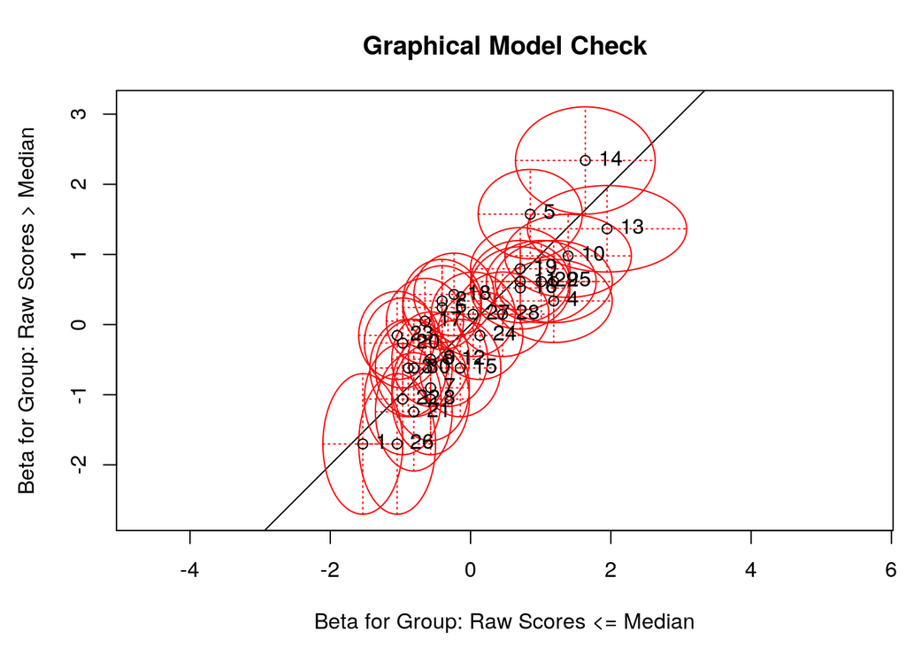

```r
plotGOF(lr_test,
        conf = list()) # outputs confidence interval ellipses
```

## 4.3 Wald-Test

The Walt-test is a test to validate for every item whether the intemparameters are the same in subpopulation (created through split criterion). Only interpret these results if the global test (Andersen-Test) is significant. This procedure is comparable to the execution of an ANOVA. The global test has to be significant to interpret.

```r
wald_test <- Waldtest(rasch_model, splitcr = "median") # median is the default

# Output ordered matrix in respect to p-values
wald_test$coef.table[order(wald_test$coef.table[,"p-value"]),]
```

```
##          z-statistic    p-value
## beta I23   2.0956613 0.03611225
## beta I2    1.7849671 0.07426665
## beta I17   1.6703897 0.09484229
## beta I20   1.6390807 0.10119646
## beta I4   -1.6256617 0.10402165
## beta I18   1.5881058 0.11226241
## beta I6    1.5529404 0.12043736
## beta I5    1.4505169 0.14691443
## beta I26  -1.1257447 0.26027362
## beta I25  -1.1009011 0.27093970
## beta I14   1.0982927 0.27207669
## beta I15  -1.0224139 0.30658506
## beta I8   -1.0005289 0.31705461
## beta I13  -0.8798835 0.37892244
## beta I21  -0.8489206 0.39592546
## beta I29  -0.7921813 0.42825497
## beta I10  -0.7461384 0.45558379
## beta I7   -0.6959569 0.48645581
## beta I28  -0.6796380 0.49673368
## beta I24  -0.6472835 0.51744845
## beta I3    0.5951251 0.55175984
## beta I30   0.4199542 0.67451892
## beta I16  -0.3976784 0.69086726
## beta I12  -0.3834373 0.70139553
## beta I1   -0.2827854 0.77734135
## beta I27   0.2544622 0.79913849
## beta I11  -0.2033186 0.83888605
## beta I22  -0.1952130 0.84522621
## beta I19   0.1853556 0.85295010
## beta I9    0.1710229 0.86420574
```

## 4.4 Rasch-mixture-analysis

Combination of Rasch-model with latent class analysis. Sub-populations

Usage of the function `raschmix` from the package `psychomix`.

```r
mix_1_grp <- raschmix(data = as.matrix(raschdat1), # data input has to be a matrix
                      k = 1, # number of latent classes
                      scores = "meanvar")
```

```
## 1 : * * *
```

```r
summary(mix_1_grp)
```

```
##
## Call:
## raschmix(data = as.matrix(raschdat1), k = 1, scores = "meanvar")
##
##        prior size post>0 ratio
## Comp.1     1  100    100     1
##
## Item Parameters:
##           Comp.1
## I1  -1.565277919
## I2  -0.051169079
## I3  -0.782252533
## I4   0.650237707
## I5   1.300618920
## I6  -0.099348706
## I7  -0.681707853
## I8  -0.731741321
## I9  -0.533602717
## I10  1.107747589
## I11  0.650237707
## I12 -0.387893834
## I13  1.511179100
## I14  2.116138586
## I15 -0.339634349
## I16  0.597098642
## I17 -0.339634349
## I18  0.093897948
## I19  0.758671686
## I20 -0.681707853
## I21 -0.936524979
## I22 -0.989219890
## I23 -0.681707853
## I24 -0.002922576
## I25  0.814380843
## I26 -1.207070963
## I27  0.093897948
## I28  0.290379732
## I29  0.758671686
## I30 -0.731741321
##
## 'log Lik.' -1753.094 (df=31)
## AIC: 3568.189   BIC: 3648.949
```

```r
mix_2_grp <- raschmix(data = as.matrix(raschdat1), # data input has to be a matrix
                      k = 2, # number of latent classes
                      scores = "meanvar")
```

```
## 2 : * * *
```

```r
summary(mix_2_grp)
```

```
##
## Call:
## raschmix(data = as.matrix(raschdat1), k = 2, scores = "meanvar")
##
##        prior size post>0 ratio
## Comp.1 0.209   21     52 0.404
## Comp.2 0.791   79    100 0.790
##
## Item Parameters:
##          Comp.1      Comp.2
## I1  -2.62136787 -1.54016726
## I2  -2.31811618  0.34304812
## I3  -2.38592491 -0.60646179
## I4  -0.25033906  0.66307293
## I5  -0.33708069  1.58580877
## I6   0.26652449 -0.45222545
## I7  -1.40182385 -0.74094934
## I8  -2.31276911 -0.55800226
## I9  -2.67159522 -0.22989826
## I10 21.74175207  0.74086716
## I11  0.07808752  0.56826732
## I12 -1.50560573 -0.32270478
## I13  0.26054448  1.64285445
## I14  1.49734274  2.07566002
## I15 -0.62340561 -0.53128591
## I16 -1.53094645  1.04033628
## I17 -2.11609864 -0.09330267
## I18 -1.30110226  0.25660872
## I19  0.27358428  0.65712316
## I20 -0.52774137 -1.02541977
## I21 -1.82583632 -0.94697063
## I22 -2.36112799 -0.87538652
## I23 -1.03531078 -0.85867744
## I24  7.76375579 -0.63551172
## I25  0.05629406  0.78679272
## I26 -1.44358370 -1.43067094
## I27 -1.77051954  0.39982060
## I28 -0.71545672  0.33225465
## I29  0.03259801  0.72140351
## I30 -0.91473146 -0.96628367
##
## 'log Lik.' -1728.137 (df=63)
## AIC: 3582.274   BIC: 3746.4
```

[output not shown]

```r
MLoef(rasch_model, splitcr = "median")
```

```
##
## Martin-Loef-Test (split criterion: median)
## LR-value: 113.371
## Chi-square df: 224
## p-value: 1
```

# 5 Itemfit and Personfit Statistics

```r
rasch_itemfit <- itemfit(person_rasch) %>% # calculates itemfit statistics
  print(visible = FALSE) # returns otherwise printed matrix

rasch_itemfit[order(rasch_itemfit[,"p-value"]),] # prints matrix ordered by p-value
```

```
##       Chisq df p-value Outfit MSQ Infit MSQ Outfit t Infit t Discrim
## I18 123.031 99   0.051      1.230     1.093    1.576   1.088   0.310
## I6  121.981 99   0.058      1.220     1.172    1.583   1.978   0.238
## I17 118.770 99   0.086      1.188     1.150    1.384   1.726   0.255
## I14 117.791 99   0.096      1.178     1.022    0.536   0.175   0.209
## I15 113.440 99   0.152      1.134     1.024    1.019   0.307   0.388
## I20 111.645 99   0.181      1.116     1.139    0.828   1.505   0.270
## I24 110.795 99   0.197      1.108     1.042    0.811   0.521   0.367
## I30 109.554 99   0.220      1.096     1.012    0.680   0.160   0.365
## I5  108.892 99   0.233      1.089     1.118    0.410   0.868   0.234
## I8  106.900 99   0.276      1.069     0.947    0.508  -0.561   0.455
## I23 106.096 99   0.295      1.061     1.056    0.463   0.640   0.341
## I11 103.243 99   0.365      1.032     1.040    0.236   0.420   0.355
## I2   99.754 99   0.460      0.998     1.068    0.027   0.823   0.345
## I3   99.031 99   0.480      0.990     0.950   -0.015  -0.519   0.424
## I21  97.975 99   0.510      0.980     0.900   -0.072  -1.019   0.473
## I27  97.214 99   0.532      0.972     1.025   -0.154   0.324   0.379
## I16  97.054 99   0.537      0.971     0.996   -0.107  -0.002   0.400
## I19  95.670 99   0.576      0.957     0.969   -0.159  -0.259   0.414
## I12  93.168 99   0.646      0.932     0.908   -0.482  -1.101   0.496
## I26  91.086 99   0.702      0.911     0.928   -0.426  -0.631   0.441
## I7   88.410 99   0.768      0.884     0.968   -0.791  -0.332   0.449
## I9   87.800 99   0.782      0.878     0.941   -0.884  -0.665   0.485
## I13  86.340 99   0.814      0.863     0.966   -0.369  -0.171   0.371
## I10  86.028 99   0.821      0.860     0.903   -0.529  -0.764   0.439
## I4   84.222 99   0.855      0.842     0.888   -0.845  -1.110   0.499
## I29  84.055 99   0.858      0.841     0.888   -0.795  -1.055   0.498
## I1   81.960 99   0.893      0.820     0.956   -0.752  -0.298   0.420
## I25  78.116 99   0.940      0.781     0.889   -1.103  -1.027   0.499
## I22  77.680 99   0.944      0.777     0.874   -1.400  -1.285   0.523
## I28  75.969 99   0.959      0.760     0.843   -1.676  -1.827   0.566
```

Given model validity 5% of Person should have p-values below 5%.

The following is from the book: Applying the Rasch Model

Infit and Outfit Mean Squares are unstandardized measures of fit and Infit/Outfit t is the standardized form

Mean Squares of the fit statistic represent the mean of the squared residuals for any item. Residuals = differences between Rasch model’s theoretical expectation of item performance and the observed performance for an item. “Mean square fit statistics indicate the size of how much misfit is revealed in the actual data”

Standardized fit statistic: mean squares are transformed regarding sample size to produce a statistic with a t distribution (acceptable values should lie between -1.96 and 1.96)

Mean squares: how much misfit; t value: how likely is the misfit

Infit statistics: information-weighted indicator of misfit; more weight is given to the performances of those persons located closer to the item’s difficulty value –> because if ability of person is close to item’s difficulty, performance of person gives more insight into item’s performnace

Outfit statistics: not weighted indicator of misfit –> more sensitive to the influence of outliers = performance of persons distant from items location

–> Therefore, often more focus on infit statistics; extreme infit statistics usually cause more concern than extreme outfit.

```r
rasch_persfit <- personfit(person_rasch) %>%
  print(visible = FALSE) # returns otherwise printed matrix

rasch_persfit[order(rasch_persfit[,"p-value"]),]
```

```
##       Chisq df p-value Outfit MSQ Infit MSQ Outfit t Infit t
## P8   57.763 29   0.001      1.925     1.003     1.83    0.10
## P26  53.532 29   0.004      1.784     1.400     2.56    2.29
## P53  45.469 29   0.026      1.516     1.405     2.58    2.73
## P17  43.796 29   0.038      1.460     1.260     1.19    1.14
## P96  39.390 29   0.094      1.313     1.066     0.75    0.31
## P30  39.174 29   0.098      1.306     1.261     1.16    1.57
## P59  38.367 29   0.114      1.279     1.203     1.56    1.45
## P90  37.693 29   0.129      1.256     1.196     0.87    0.92
## P50  37.478 29   0.134      1.249     1.052     1.36    0.42
## P56  36.956 29   0.147      1.232     1.253     1.32    1.77
## P82  36.976 29   0.147      1.233     1.270     0.98    1.43
## P19  36.895 29   0.149      1.230     1.105     0.76    0.58
## P89  36.555 29   0.158      1.219     1.128     0.84    0.69
## P73  36.420 29   0.162      1.214     1.176     1.18    1.18
## P20  35.939 29   0.175      1.198     1.162     0.67    0.85
## P78  35.823 29   0.179      1.194     1.082     0.93    0.53
## P18  35.705 29   0.182      1.190     0.929     0.65   -0.30
## P2   35.676 29   0.183      1.189     1.089     0.50    0.34
## P36  35.106 29   0.201      1.170     0.936     0.85   -0.42
## P60  34.715 29   0.214      1.157     1.050     0.93    0.41
## P92  33.391 29   0.262      1.113     1.041     0.46    0.26
## P27  32.986 29   0.278      1.100     1.157     0.46    0.99
## P71  32.928 29   0.281      1.098     1.119     0.59    0.83
## P31  32.835 29   0.284      1.095     1.057     0.44    0.40
## P33  32.735 29   0.289      1.091     1.129     0.46    0.89
## P48  32.653 29   0.292      1.088     0.930     0.54   -0.49
## P69  32.383 29   0.303      1.079     1.100     0.49    0.71
## P85  32.327 29   0.306      1.078     1.076     0.37    0.44
## P10  31.693 29   0.333      1.056     1.036     0.27    0.22
## P93  31.561 29   0.339      1.052     1.053     0.27    0.31
## P77  31.526 29   0.341      1.051     1.080     0.31    0.52
## P74  31.063 29   0.362      1.035     1.035     0.25    0.27
## P63  30.998 29   0.366      1.033     0.966     0.25   -0.20
## P46  30.891 29   0.371      1.030     1.039     0.22    0.33
## P100 30.880 29   0.371      1.029     1.017     0.24    0.17
## P54  30.871 29   0.372      1.029     1.074     0.22    0.58
## P75  30.725 29   0.378      1.024     1.062     0.19    0.44
## P11  30.590 29   0.385      1.020     1.038     0.19    0.23
## P15  30.421 29   0.393      1.014     0.956     0.16   -0.13
```

[output cut: 46 more lines]

```
## P22  23.396 29   0.758      0.780     0.899    -0.72   -0.54
## P28  23.283 29   0.763      0.776     0.890    -0.85   -0.66
## P51  23.273 29   0.764      0.776     0.816    -1.32   -1.42
## P94  23.083 29   0.773      0.769     0.801    -0.59   -0.79
## P38  22.775 29   0.787      0.759     0.824    -1.20   -1.30
## P47  22.537 29   0.797      0.751     0.808    -1.38   -1.48
## P14  22.305 29   0.807      0.743     0.896    -0.62   -0.40
## P41  21.645 29   0.835      0.722     0.770    -1.42   -1.75
## P44  21.282 29   0.849      0.709     0.763    -1.65   -1.87
## P4   20.991 29   0.859      0.700     0.900    -0.37   -0.16
## P61  20.998 29   0.859      0.700     0.736    -1.90   -2.02
## P7   20.707 29   0.870      0.690     0.880    -0.52   -0.31
## P1   19.836 29   0.898      0.661     1.001     0.18    0.31
## P98  18.049 29   0.943      0.602     0.953    -0.63    0.00
## P79  17.341 29   0.957      0.578     0.667    -2.01   -2.03
```

```r
sep_rel <- SepRel(person_rasch)
summary(sep_rel)
```

```
##        Separation Reliability: 0.8373
##
##             Observed Variance: 1.2338 (Squared Standard Deviation)
## Mean Square Measurement Error: 0.2007 (Model Error Variance)
```

person separation Reliability: proportion of person variance that is not due to error. Concept of person separation reliability is very similar but not identifal to reliability indices such as Cronbach’s $\alpha$

In this example the person separation reliability equals 0.84

```r
# person separation reliability by hand
var(person_rasch$theta.table$`Person Parameter`)/(sep_rel$MSE + var(person_rasch$theta.table$`Person Parameter`))
```

```
## [1] 0.8600965
```

```r
(var(person_rasch$theta.table$`Person Parameter`) - sep_rel$MSE)/ var(person_rasch$theta.table$`Person Parameter`)
```

```
## [1] 0.8373398
```

```r
# item separation reliability

(var(rasch_model$betapar) - sep_rel$MSE)/var(rasch_model$betapar)
```

```
## [1] 0.7392008
```